# Pyhton Notes

Python is Interpreted, very-high-level programming language.

Only became popular in the last decade or so.

Python was introduced by Guido van Rossum

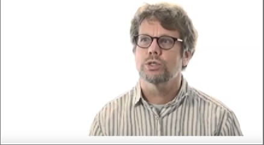

Python flavours lets the user integration easier. Though there are many flavours of python the following are most commonly used python for day to day needs;

1. Core python / cpython / python --- [Widely used]
1. Jython (corepython + java frameworks integration)
1. IronPython (corepython + micrsoft .net framework)
1. pypy – implemented in rpypython

```python
import platform
platform.python_implementation()
```

```
'CPython'
```

There are two versions of python.

```
1) python 2.x: Highly recommended to start with

2) python 3.x: Recommended for advanced users
```

```python
import sys
sys.version
```

```
'3.9.13 (main, Aug 25 2022, 23:51:50) [MSC v.1916 64 bit (AMD64)]'
```

# How Python works?

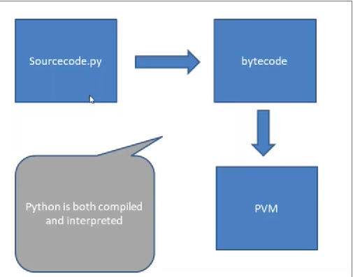

```python
# import sys
import keyword
```

# Keywords

Keywords are the reserved words in Python and can't be used as an identifier

```python
print(keyword.kwlist) # List all Python Keywords
```

[output not shown]

```python
len(keyword.kwlist)
```

```
36
```

# Identifiers

An identifier(label) is a name given to entities like class, functions, variables, etc. It helps to differentiateone entity from another.

Identifiers can be alphanumeric but it should not start from number

```python
1var=10   # Identifier can't start with a digit
```

```
  File "C:\Users\Lenovo\AppData\Local\Temp/ipykernel_9508/434924443.py", line 1
    1var=10   # Identifier can't start with a digit
     ^
SyntaxError: invalid syntax
```

```python
val2@=35 	# Identifier can't use special symbols
```

```
---------------------------------------------------------------------------
NameError                                 Traceback (most recent call last)
~\AppData\Local\Temp/ipykernel_11208/3475134109.py in <module>
----> 1 val2@=35        # Identifier can't use special symbols

NameError: name 'val2' is not defined
```

```python
import=125          # Keywords can't be used as identifiers
```

```
  File "C:\Users\Lenovo\AppData\Local\Temp/ipykernel_11208/3321359636.py", line 1
    import=125          # Keywords can't be used as identifiers
          ^
SyntaxError: invalid syntax
```

```python
"""
Correct way of defining an identifier
(Identifiers can be a combination of letters in lowercase (a to z) or uppercase (
"""
val2=10
```

```python
val_=99
```

# Comments in Python

Comments can be used to explain the code for more readabilty.

```python
'''
Multiple
line
comment
'''
val=10
```

```python
"""
Multiple
line
comment
"""
val=10
```

# Statements

Instructions that a Python interpreter can execute.

```python
#Single Line statement
p1=10+20

p1
```

```
30
```

```python
#Single Line statement
p1=['a', 'b', 'c', 'd' ]

p1
```

```
['a', 'b', 'c', 'd']
```

```python
# Multi Line statement
p1=10+20 \
   +40+50 \
   +60+70


p1
```

```
250
```

```python
#Multi Line statement
p1=['a',
    'b',
    'c',
    'd' ]
```

# Indentation

Indentation refers to the spaces at the beginning of a code line. It is very important as Python usesindentation to indicate a block of code.If the indentation is not correct we will endup with IndentationError error.

```python
p=10
if p==10:
    print('P is equal to 10')    # correct indentation
```

```
P is equal to 10
```

```python
# if indentation is skipped we will encounter "IndentationError: expected an indented block
p=10
if p==10:
print('P is equal to 10')    # wrong indentation
```

```
  File "C:\Users\Lenovo\AppData\Local\Temp/ipykernel_11208/2299842483.py", line 4
    print('P is equal to 10')    # wrong indentation
    ^
IndentationError: expected an indented block
```

```python
for i in range(1,5):
    print(i)      # correct indentation
```

```
1
2
3
4
```

```python
for i in range(1,5): print(i)   # correct indentation
```

```
1
2
3
4
```

```python
j=20
for i in range(1,5):
    print(i)  #inner loop
print(j) #outer loop
```

```
1
2
3
4
20
```

# Docstrings

1) Docstrings provide a convenient way of associating documentation with functions, classes,methods or modules.

2) They appear right after the definition of a function, method, class, or module.

```python
def square(num):
    '''Square Function :- This function will return the square of a number'''
    return num**2
```

```python
square(2)
```

```
4
```

```python
square.__doc__
```

```
'Square Function :- This function will return the square of a number'
```

```python
def evenodd(num):
    '''evenodd Function :- This function will test whether a numbr is Even or Odd'''
    if  num%2==0:
        print("Even Number")
    else:
        print("Odd Number")
```

```python
evenodd(2)
```

```
Even Number
```

```python
evenodd(3)
```

```
Odd Number
```

```python
evenodd.__doc__
```

```
'evenodd Function :- This function will test whether a numbr is Even or Odd'
```

# Variables

A Python variable is a reserved memory location to store values.A variable is created the momentyou first assign a value to it.

```python
p = 30
```

```python
'''
id()
function returns the “identity” of the object.The identity of an object
                    - Is an integer
                    - Guaranteed to be unique
                    - Constant for this object during its lifetime.
'''
id(p)
```

```
1486439869648
```

```python
hex(id(p))        # Memory address of the variable
```

```
'0x15a16b86cd0'
```

```python
p=20
q=20
r=p
p,type(p),hex(id(p))
```

[output not shown]

```python
r, type(r), hex(id(r))
```

[output not shown]

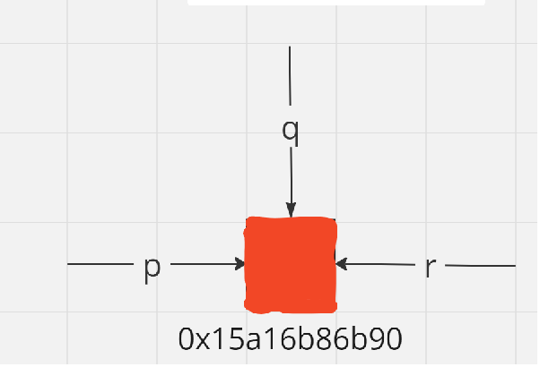

```python
p=20
p=p+10# Variable Overwriting
p
```

```
30
```

# Data Types

```python
val1=10                                             # Integer data type
print(val1)
print(type(val1))                                   # type of object
print(sys.getsizeof(val1))                          # size of integer object in bytes
print(val1," is Integer?",isinstance(val1,int))     # val1 is an instance of intiger
```

```
10
<class 'int'>
28
10  is Integer? True
```

```python
val2=92.78                                         # Float data type
print(val2)
print(type(val2))                                  # type of object
print(sys.getsizeof(val2))                         # size of float object in bytes
print(val2," is float?",isinstance(val2,float))    # Val2 is an instance of float
```

```
92.78
<class 'float'>
24
92.78  is float? True
```

```python
val3=25+10j                                        # Complex data type
print(val3)
print(type(val3))                                  # type of object
print(sys.getsizeof(val3))                         # size of float object in bytes
print(val3," is complex?",isinstance(val3,complex))# val3
```

```
(25+10j)
<class 'complex'>
32
(25+10j)  is complex? True
```

```python
sys.getsizeof(int())                               # size of integer object in bytes
```

```
24
```

```python
sys.getsizeof(float())                             # size of float object in bytes
```

```
24
```

```python
sys.getsizeof(complex())                           # size of complex object in bytes
```

```
32
```

# Boolean

Boolean data type can have only two possible values true or false .

```python
bool1=True
```

```python
bool2=False
```

```python
print(type(bool1))
```

```
<class 'bool'>
```

```python
print(type(bool2))
```

```
<class 'bool'>
```

```python
isinstance(bool1, bool)
```

```
True
```

```python
bool(0)
```

```
False
```

```python
bool(1)
```

```
True
```

```python
bool(None)
```

```
False
```

```python
bool()
```

```
False
```

# Strings

# String Creation

```python
str1="HELLO PYTHON"
print(str1)
```

```
HELLO PYTHON
```

```python
mystr='Hello World'             # Define string using single quotes
print(mystr)
```

```
Hello World
```

```python
mystr="Hello World"            # Define string using double quotes
print(mystr)
```

```
Hello World
```

```python
mystr='''Hello
            World '''         # Define string using triple quotes
print(mystr)
```

```
Hello
            World
```

```python
mystr="""Hello
                World"""     # Define string using triple quotes
print(mystr)
```

```
Hello
                World
```

```python
mystr=('Happy '
        'Monday '
        'Everyone'
        )
print(mystr)
```

```
Happy Monday Everyone
```

```python
mystr2='Woohoo '
mystr2=mystr2*5
mystr2
```

```
'Woohoo Woohoo Woohoo Woohoo Woohoo '
```

```python
len(mystr2)                   # Length of string
```

```
35
```

# String Indexing

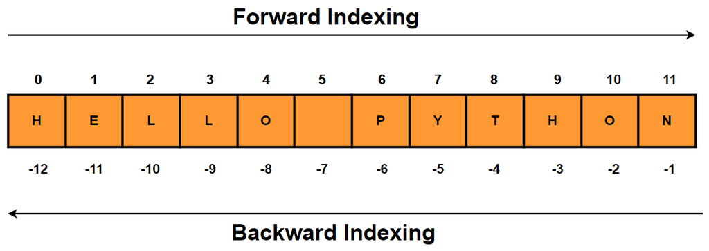

```python
str1
```

```
'HELLO PYTHON'
```

```python
str1[0]                    # First character in string "str1"
```

```
'H'
```

```python
str1[len(str1)-1]         # Last character in string using len function
```

```
'N'
```

```python
str1[-1]
```

```
'N'
```

```python
str1[6]                 #Fetch 7th element of the string
```

```
'P'
```

```python
str1[5]
```

```
' '
```

# String Slicing

```python
str1[0:5]             # String slicing - Fetch all characters from 0 to 5 index location excluding lasr index(5)
```

```
'HELLO'
```

```python
str1[0:-1] #compination of fwd and bkwd slicing
```

```
'HELLO PYTHO'
```

```python
str1[::-1] #Reverse Sliscing
```

```
'NOHTYP OLLEH'
```

```python
str1[2::-1]
```

```
'LEH'
```

# Update & Delete String

```python
str1
```

```
'HELLO PYTHON'
```

```python
str1[0:5]='HELAA' #Strings are immutable So the elements of a string  cannot modify
```

```
---------------------------------------------------------------------------
TypeError                                 Traceback (most recent call last)
~\AppData\Local\Temp/ipykernel_11208/3026157716.py in <module>
----> 1 str1[0:5]='HELAA' #Strings are immutable So the elements of a string  cannot modify

TypeError: 'str' object does not support item assignment
```

```python
del =str1 # Delete the string
str1
```

```
  File "C:\Users\Lenovo\AppData\Local\Temp/ipykernel_11208/4115970601.py", line 1
    del =str1 # Delete the string
        ^
SyntaxError: invalid syntax
```

# String concatenation

```python
# String concatenation
s1="Hello"
s2="coder"
s3=s1+s2
print(s3)
```

```
Hellocoder
```

```python
# String concatenation
s1="Hello"
s2="coder"
s3=s1+" "+s2
print(s3)
```

```
Hello coder
```

# Iterating through a String

```python
mystr1="Hello Everyone"
```

```python
# Iteration
for i in mystr1:
    print(i)
```

```
H
e
l
l
o

E
v
e
r
y
o
n
e
```

```python
for i in enumerate(mystr1):
    print(i)
```

```
(0, 'H')
(1, 'e')
(2, 'l')
(3, 'l')
(4, 'o')
(5, ' ')
(6, 'E')
(7, 'v')
(8, 'e')
(9, 'r')
(10, 'y')
(11, 'o')
(12, 'n')
(13, 'e')
```

```python
enumerate(mystr1)
```

```
<enumerate at 0x15a1c9cebc0>
```

```python
list(enumerate(mystr1)) ## Enumerate method adds a counter to an iterable and return tuble of index and string
```

```
[(0, 'H'),
 (1, 'e'),
 (2, 'l'),
 (3, 'l'),
 (4, 'o'),
 (5, ' '),
 (6, 'E'),
 (7, 'v'),
 (8, 'e'),
 (9, 'r'),
 (10, 'y'),
 (11, 'o'),
 (12, 'n'),
 (13, 'e')]
```

```python
# String membership
mystr1="Hello Everyone"
print('Hello' in mystr1)      # Check whether substring "Hello" is present in mstr1
print('Everyone' in mystr1)   # Check whether substring "Everyone" is present in mystr1
print('Hi' in mystr1)         # Check whether substring "Hi" is present in string "mystr1
```

```
True
True
False
```

```python
"""
The partition() method searches for a specified string and splits the string into
- The first element contains the part before the argument string.
- The second element contains the argument string.
- The third element contains the part after the argument string.
"""
str5="Natural language processing with Python and R and Java"
L=str5.partition("and")
print(L)
```

```
('Natural language processing with Python ', 'and', ' R and Java')
```

```python
"""
The rpartition() method searches for the last occurence of the specified string a
containing three elements.
- The first element contains the part before the argument string.
- The second element contains the argument string.
- The third element contains the part after the argument string.
"""
str5="Natural language processing with Python and R and Java"
L=str5.rpartition("and")
print(L)
```

```
('Natural language processing with Python and R ', 'and', ' Java')
```

# String Functions

```python
mystr2=" Hello Everyone "
mystr2
```

```
' Hello Everyone '
```

```python
dir(mystr2)
```

```
['__add__',
 '__class__',
 '__contains__',
 '__delattr__',
 '__dir__',
 '__doc__',
 '__eq__',
 '__format__',
 '__ge__',
 '__getattribute__',
 '__getitem__',
 '__getnewargs__',
 '__gt__',
 '__hash__',
 '__init__',
 '__init_subclass__',
 '__iter__',
 '__le__',
 '__len__',
 '__lt__',
 '__mod__',
 '__mul__',
 '__ne__',
 '__new__',
 '__reduce__',
 '__reduce_ex__',
 '__repr__',
 '__rmod__',
 '__rmul__',
 '__setattr__',
 '__sizeof__',
 '__str__',
 '__subclasshook__',
 'capitalize',
 'casefold',
 'center',
 'count',
 'encode',
 'endswith',
 'expandtabs',
```

[output cut: 25 more lines]

```
 'rfind',
 'rindex',
 'rjust',
 'rpartition',
 'rsplit',
 'rstrip',
 'split',
 'splitlines',
 'startswith',
 'strip',
 'swapcase',
 'title',
 'translate',
 'upper',
 'zfill']
```

```python
mystr2.strip()                # Removes white space from begining & end
```

```
'Hello Everyone'
```

```python
mystr2.rstrip()               # Removes all whitespaces at the end of the string
```

```
' Hello Everyone'
```

```python
mystr2.lstrip()               # Removes all whitespaces at the begining of the string
```

```
'Hello Everyone '
```

```python
mystr2="*********Hello Everyone***********All the Best**********"
mystr2
```

```
'*********Hello Everyone***********All the Best**********'
```

```python
mystr2.strip('*')           # Removes all '*' characters from begining & end of the string
```

```
'Hello Everyone***********All the Best'
```

```python
mystr2.rstrip('*')          # Removes all '*' characters at the end of the string
```

```
'*********Hello Everyone***********All the Best'
```

```python
mystr2.lstrip('*')          # Removes all '*' characters at the end of the string
```

```
'Hello Everyone***********All the Best**********'
```

```python
mystr2=" Hello Everyone "
mystr2.lower()                  # Return whole string in lowercase
```

```
' hello everyone '
```

```python
mystr2.upper()                  # Return whole string in uppercase
```

```
' HELLO EVERYONE '
```

```python
mystr2.replace("He","Ho")       #Replace substring "He" with "Ho"
```

```
' Hollo Everyone '
```

```python
mystr2.replace(" ","")          # Remove all whitespaces using replace function
```

```
'HelloEveryone'
```

```python
mystr5="one two Three one two two three"
mystr5.count("one")                 # Number of times substring "one" occurred in string.
```

```
2
```

```python
mystr5.count("two")                 # Number of times substring "two" occurred in string.
```

```
3
```

```python
mystr5.startswith("one")            # Return boolean value True if string starts with "one"
```

```
True
```

```python
mystr5.endswith("three")            # Return boolean value True if string ends with "three"
```

```
True
```

```python
mystr4="one two three four one two two three five five six seven six seven one"
```

```python
mylist=mystr4.split()              # Split String into substrings
mylist
```

```
['one',
 'two',
 'three',
 'four',
 'one',
 'two',
 'two',
 'three',
 'five',
 'five',
 'six',
 'seven',
 'six',
 'seven',
 'one']
```

```python
# Combining string & numbers using format method
item1=40
item2=55
item3=77
```

```python
res="Cost of item1 , item2 and item3 are {} , {} and {}"
```

```python
print(res.format(item1,item2,item3))
```

```
Cost of item1 , item2 and item3 are 40 , 55 and 77
```

```python
str2=" WELCOME EVERYONE "
str2=str2.center(100)          # center align the string using a specific character as t
print(str2)
```

```
                                          WELCOME EVERYONE
```

```python
str2=" WELCOME EVERYONE "
str2=str2.center(100,'*')       # center align the string using a specific character
print(str2)
```

```
***************************************** WELCOME EVERYONE *****************************************
```

```python
str2=" WELCOME EVERYONE "
str2=str2.rjust(50)            # Right align the string using a specific character as the
print(str2)
```

```
                                 WELCOME EVERYONE
```

```python
str2=" WELCOME EVERYONE "
str2=str2.rjust(50,'*')       # Right align the string using a specific character ('*
print(str2)
```

```
******************************** WELCOME EVERYONE
```

```python
str2=" WELCOME EVERYONE "
str2=str2.ljust(50,'*')       # Left align the string using a specific character ('*
print(str2)
```

```
 WELCOME EVERYONE ********************************
```

```python
str4="one two three four five six seven"
loc=str4.find("five")        # Find the location of word 'five' in the string "str4"
print(loc)
```

```
19
```

```python
mystr6='123456789'
print(mystr6.isalpha())     # returns True if all the characters in the text are lett
print(mystr6.isalnum())     # returns True if a string contains only letters or numb
print(mystr6.isdecimal())   # returns True if all the characters are decimals (0-9)
print(mystr6.isnumeric())   # returns True if all the characters are numeric (0-9)
```

```
False
True
True
True
```

```python
mystr6='abcde'
print(mystr6.isalpha())                    # returns True if all the characters in the text are lett
print(mystr6.isalnum())                    # returns True if a string contains only letters or numb
print(mystr6.isdecimal())                  # returns True if all the characters are decimals (0-9)
print(mystr6.isnumeric())                  # returns True if all the characters are numeric (0-9)
```

```
True
True
False
False
```

```python
mystr6='abc12309'
print(mystr6.isalpha())                  # returns True if all the characters in the text are lett
print(mystr6.isalnum())                  # returns True if a string contains only letters or numb
print(mystr6.isdecimal())                # returns True if all the characters are decimals (0-9)
print(mystr6.isnumeric())                # returns True if all the characters are numeric (0-9)
```

```
False
True
False
False
```

```python
mystr7='ABCDEF'
print(mystr7.isupper())                  # Returns True if all the characters are in upper case
print(mystr7.islower())                  # Returns True if all the characters are in lower case
```

```
True
False
```

```python
mystr8='abcdef'
print(mystr8.isupper())                 # Returns True if all the characters are in upper case
print(mystr8.islower())                 # Returns True if all the characters are in lower case
```

```
False
True
```

```python
str6="one two three four one two two three five five six one ten eight ten nine"
loc=str6.rfind("one")                   # last occurrence of word 'one' in string "str6"
print(loc)
```

```
51
```

```python
loc=str6.rindex("one")                  # last occurrence of word 'one' in string "str6"
print(loc)
```

```
51
```

```python
txt=" abc def ghi "
txt.rstrip()
```

```
' abc def ghi'
```

```python
txt=" abc def ghi "
txt.lstrip()
```

```
'abc def ghi '
```

```python
txt=" abc def ghi "
txt.strip()
```

```
'abc def ghi'
```

# Using Escape Character

```python
#Using double quotes in the string is not allowed.
mystr="My favourite TV Series is "GameofThrones""
```

```
  File "C:\Users\Lenovo\AppData\Local\Temp/ipykernel_11208/569859150.py", line 2
    mystr="My favourite TV Series is "GameofThrones""
                                      ^
SyntaxError: invalid syntax
```

```python
#Using escape character to allow illegal characters
mystr="My favourite TV Series is \"GameofThrones\""
print(mystr)
```

```
My favourite TV Series is "GameofThrones"
```

# List

1) List is an ordered sequence of items.

2) We can have different data types under a list. E.g we can have integer, float and string items ina same list.

# List Creation

```python
list1=[]                     # Empty List
```

```python
print(type(list1))
```

```
<class 'list'>
```

```python
list2=[10,30,60]           # List of integers numbers
```

```python
list3=[10.77,30.66,60.89]  # List of float numbers
```

```python
list4=['one','two',"three"]                      # List of strings
```

```python
list5=['coder',25,[50,100],[150,90]]              # Nested Lists
```

```python
list6=[100,'coder',17.765]                        # List of mixed data types
```

```python
list7=['coder',25,[50,100],[150,90] , {'John','David'}]
```

```python
len(list6)                                       #Length of list
```

```
3
```

# List Indexing

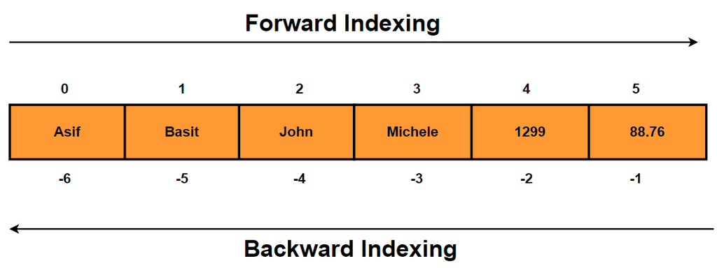

```python
list2[0]                         # Retreive first element of the list
```

```
10
```

```python
list4[0]                        # Retreive first element of the list
```

```
'one'
```

```python
list4[0][0]                     # Nested indexing -
                                # Access the first character of the first list element
```

```
'o'
```

```python
list4[-1]                      # Last item of the list
```

```
'three'
```

```python
list5[-1]                     # Last item of the list
```

```
[150, 90]
```

# List Slicing

```python
mylist=['one','two','three','four','five','six','seven','eight']
```

```python
mylist[0:3]                 # Return all items from 0th to 3rd index location excluding the item
```

```
['one', 'two', 'three']
```

```python
mylist[2:5]                # List all items from 2nd to 5th index location excluding the item at mylist
```

```
['three', 'four', 'five']
```

```python
mylist[:3]                # Return first three items
```

```
['one', 'two', 'three']
```

```python
mylist[:2]               # Return first two items
```

```
['one', 'two']
```

```python
mylist[-3:]             # Return last three items
```

```
['six', 'seven', 'eight']
```

```python
mylist[-2:]            # Return last two items
```

```
['seven', 'eight']
```

```python
mylist[-1]            # Return last item of the list
```

```
'eight'
```

```python
mylist[:]           # Return whole list
```

```
['one', 'two', 'three', 'four', 'five', 'six', 'seven', 'eight']
```

```python
mylist[::-1]           # Reverse whole list
```

```
['eight', 'seven', 'six', 'five', 'four', 'three', 'two', 'one']
```